# Experimentos com um fator (principal): análise de variância

Rumenick Pereira da Silva

27 de abril de 2019

## Problema 1 (Planejamento Quadrados latinos)

[output not shown]

Obs.: O número de linhas, colunas e tratamentos, deve ser o mesmo (Sudoku).

### Solucionando o problema 1

#### Característica do experimento:

- Unidade experimental: 1/5 do lote de material
- Resposta: tempo de reação
- Um fator: ingredientes
  - níveis: A, B, C, D e E
- Blocos: dia e o lote
- Quantas replicações de cada tratamento: 5
- Quantos ensaios: 5 x 5 = 25
- Sabemos algo sobre a ordem de execução de cada um dos ensaios?
- Tipo de experimento: extensão do delineamento aleatorizado em blocos completos ou ou delineamento em quadrados latinos
1. Resposta:

Hipóteses a serem testadas:

- Em português
  - $H_{0}$: não há diferença no tempo de reação (resposta) entre os ingredientes usados no processo químico;
  - $H_{1}$: há diferença no tempo de reação (resposta) entre os ingredientes usados no processo químico;
- Em “Estatisquês”
  - $H_{0}$: $\tau_1 = \tau_2 = \tau_3 = \tau_4 = \tau_5 = 0$
  - $H_{1}$: $\tau_k \neq 0, k = 1, 2, 3, 4, 5$.

Efeito de linha (lotes):

- Em português
  - $H_{0}$: não há diferença no tempo de reação (resposta) entre os lotes usados no processo químico;
  - $H_{1}$: há diferença no tempo de reação (resposta) entre os lotes usados no processo químico;
- Em “Estatisquês”
  - $H_{0}$: $\alpha_1 = \alpha_2 = \alpha_3 = \alpha_4 = \alpha_5 = 0$
  - $H_{1}$: $\alpha_i \neq 0, i = 1, 2, 3, 4, 5$.

Efeito de coluna (Dia):

- Em português
  - $H_{0}$: não há diferença no tempo de reação (resposta) entre os dias usados no processo químico;
  - $H_{1}$: há diferença no tempo de reação (resposta) entre os dias usados no processo químico;
- Em “Estatisquês”
  - $H_{0}$: $\beta_1 = \beta_2 = \beta_3 = \beta_4 = \beta_5 = 0$
  - $H_{1}$: $\beta_j \neq 0, j = 1, 2, 3, 4, 5$.

Análise dos dados:

Carregando o conjunto de dados:

```r
# Para instalar os pacotes:
# pkgs <- c("dplyr", "tidyr", "ggplot2")
# install.packages(pkgs)

# Carregando pacotes:
library(tidyr) # Para organização de dados
library(dplyr) # Para manipulação de dados
library(reshape2)# Para manipulação de dados
library(ggplot2) # Para fazer gráficos

# Carregando os dados (forma do livro):


ingredients <- matrix(c("A = 8", "B = 7", "D = 1", "C = 7", "E = 3",
                      "C = 11", "E = 2", "A = 7", "D = 3", "B = 8",
                      "B = 4",  "A = 9", "C = 10", "E = 1", "D = 5",
                      "D = 6",  "C = 8", "E = 6", "B = 6", "A = 10",
                      "E = 4",  "D = 2", "B = 3", "A = 8", "C = 8"),
                      ncol = 5,
                      nrow = 5,
                      dimnames = list(paste0("lote", 1:5), paste0("dia", 1:5)))


## Conferindo os dados:
ingredients
```

```
##       dia1    dia2     dia3     dia4     dia5
## lote1 "A = 8" "C = 11" "B = 4"  "D = 6"  "E = 4"
## lote2 "B = 7" "E = 2"  "A = 9"  "C = 8"  "D = 2"
## lote3 "D = 1" "A = 7"  "C = 10" "E = 6"  "B = 3"
## lote4 "C = 7" "D = 3"  "E = 1"  "B = 6"  "A = 8"
## lote5 "E = 3" "B = 8"  "D = 5"  "A = 10" "C = 8"
```

```r
# Organizando os dados para análise:
ingredients <-
  melt(ingredients, varnames = c("lote", "dia")) %>%
  separate(value, into = c("trat", "resp"), sep = " = ") %>%
  mutate(resp = as.numeric(resp))

## Conferindo os dados:
ingredients
```

```
##     lote  dia trat resp
## 1  lote1 dia1    A    8
## 2  lote2 dia1    B    7
## 3  lote3 dia1    D    1
## 4  lote4 dia1    C    7
## 5  lote5 dia1    E    3
## 6  lote1 dia2    C   11
## 7  lote2 dia2    E    2
## 8  lote3 dia2    A    7
## 9  lote4 dia2    D    3
## 10 lote5 dia2    B    8
## 11 lote1 dia3    B    4
## 12 lote2 dia3    A    9
## 13 lote3 dia3    C   10
## 14 lote4 dia3    E    1
## 15 lote5 dia3    D    5
## 16 lote1 dia4    D    6
## 17 lote2 dia4    C    8
## 18 lote3 dia4    E    6
## 19 lote4 dia4    B    6
## 20 lote5 dia4    A   10
## 21 lote1 dia5    E    4
## 22 lote2 dia5    D    2
## 23 lote3 dia5    B    3
## 24 lote4 dia5    A    8
## 25 lote5 dia5    C    8
```

```r
## Salvando o conjunto de dados:
# save(ingredients, file = "./data/ingredients.rda")
```

Análise gráfica:

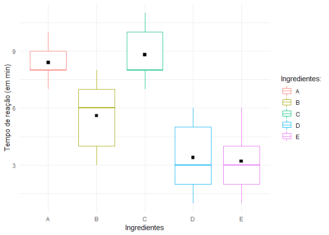

```r
ingredients %>%
  ggplot(aes(x = trat, y = resp, colour = trat)) +
  geom_boxplot() +
  stat_summary(fun.y = "mean", colour = "black", size = 2, geom = "point", shape = 15)+
  labs(x = "Ingredientes",
       y = "Tempo de reação (em min)") +
  scale_colour_discrete(name = "Ingredientes:") +
  theme_minimal()
```

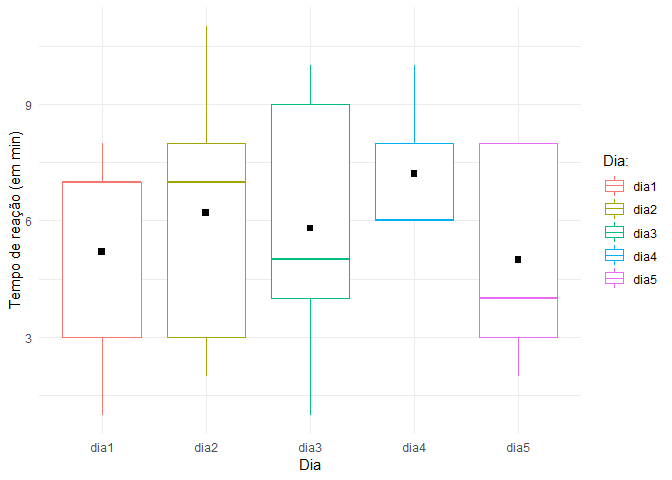

```r
ingredients %>%
  ggplot(aes(x = dia, y = resp, colour = dia)) +
  geom_boxplot() +
  stat_summary(fun.y = "mean", colour = "black", size = 2, geom = "point", shape = 15)+
  labs(x = "Dia",
       y = "Tempo de reação (em min)") +
  scale_colour_discrete(name = "Dia:") +
  theme_minimal()
```

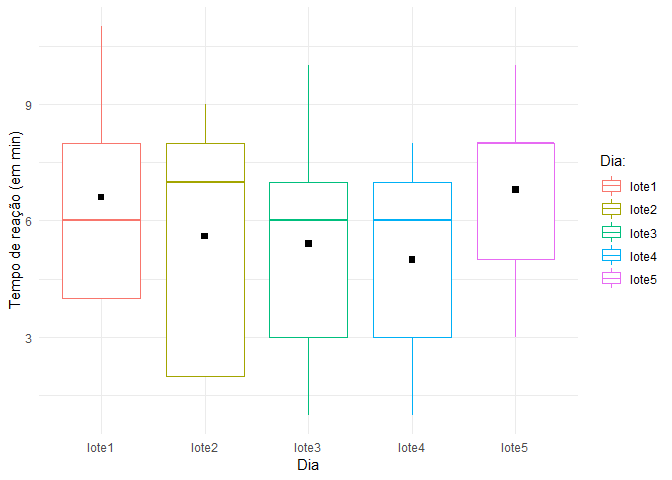

```r
ingredients %>%
  ggplot(aes(x = lote, y = resp, colour = lote)) +
  geom_boxplot() +
  stat_summary(fun.y = "mean", colour = "black", size = 2, geom = "point", shape = 15)+
  labs(x = "Dia",
       y = "Tempo de reação (em min)") +
  scale_colour_discrete(name = "Dia:") +
  theme_minimal()
```

Modelo Estatístico para o problema do tempo de reação:

$$y_{ijk} = \mu + \tau_{k} + \alpha_{i} + \beta_{j} + \epsilon_{ijk},\\
i = 1, 2,\ldots, 5;\\
j = 1, 2,\ldots, 5;\\
k = 1, 2,\ldots, 5,$$

sendo:

- $y_{ijk}$: é a observação na i-ésima linha e j-ésima coluna do k-ésimo tratamento;
- $\mu$: o efeito da média geral;
- $\tau_{k}$: o efeito do k-ésimo nível do fator principal (ingredientes), definido como:

$$\tau_{k} = \mu_{..k} - \mu;$$

- $\alpha_{i}$ é o efeito da i-ésima linha, definido como:

$$\alpha_{i} = \mu_{i..} - \mu;$$

- $\beta_{j}$ é o efeito da j-ésima coluna, definido como:

$$\beta_{j} = \mu_{.j.} - \mu;$$

- $\epsilon_{ijk}$: o erro aleatório associado a observação $y_{ijk}$.

Suposições:

$$\epsilon_{ijk} \overset{\textrm{i.i.d.}}{\sim} N(0, \sigma^2)$$

ANOVA utilizando o `R`

```r
# Obtendo as somas de quadrados e seus respectivos graus de liberdade:
ingredients.av <- aov(formula = resp ~ trat + lote + dia, data = ingredients)

# Visualizando o resultado:
ingredients.av
```

```
## Call:
##    aov(formula = resp ~ trat + lote + dia, data = ingredients)
##
## Terms:
##                   trat   lote    dia Residuals
## Sum of Squares  141.44  12.24  15.44     37.52
## Deg. of Freedom      4      4      4        12
##
## Residual standard error: 1.768238
## Estimated effects may be unbalanced
```

```r
# Obtendo a ANOVA:
anova(ingredients.av)
```

```
## Analysis of Variance Table
##
## Response: resp
##           Df Sum Sq Mean Sq F value    Pr(>F)
## trat       4 141.44  35.360 11.3092 0.0004877 ***
## lote       4  12.24   3.060  0.9787 0.4550143
## dia        4  15.44   3.860  1.2345 0.3476182
## Residuals 12  37.52   3.127
## ---
## Signif. codes:  0 '***' 0.001 '**' 0.01 '*' 0.05 '.' 0.1 ' ' 1
```

```r
# Retirando o dia e o lote

# Obtendo as somas de quadrados e seus respectivos graus de liberdade:
ingredients.av <- aov(formula = resp ~ trat, data = ingredients)

# Visualizando o resultado:
ingredients.av
```

```
## Call:
##    aov(formula = resp ~ trat, data = ingredients)
##
## Terms:
##                   trat Residuals
## Sum of Squares  141.44     65.20
## Deg. of Freedom      4        20
##
## Residual standard error: 1.805547
## Estimated effects may be unbalanced
```

```r
# Obtendo a ANOVA:
anova(ingredients.av)
```

```
## Analysis of Variance Table
##
## Response: resp
##           Df Sum Sq Mean Sq F value    Pr(>F)
## trat       4 141.44   35.36  10.847 7.672e-05 ***
## Residuals 20  65.20    3.26
## ---
## Signif. codes:  0 '***' 0.001 '**' 0.01 '*' 0.05 '.' 0.1 ' ' 1
```

Teste de Tukey

```r
ingredients.tu <- TukeyHSD(ingredients.av)
ingredients.tu
```

```
##   Tukey multiple comparisons of means
##     95% family-wise confidence level
##
## Fit: aov(formula = resp ~ trat, data = ingredients)
##
## $trat
##     diff        lwr        upr     p adj
## B-A -2.8 -6.2170769  0.6170769 0.1422785
## C-A  0.4 -3.0170769  3.8170769 0.9964951
## D-A -5.0 -8.4170769 -1.5829231 0.0024002
## E-A -5.2 -8.6170769 -1.7829231 0.0016149
## C-B  3.2 -0.2170769  6.6170769 0.0732844
## D-B -2.2 -5.6170769  1.2170769 0.3360975
## E-B -2.4 -5.8170769  1.0170769 0.2578390
## D-C -5.4 -8.8170769 -1.9829231 0.0010867
## E-C -5.6 -9.0170769 -2.1829231 0.0007318
## E-D -0.2 -3.6170769  3.2170769 0.9997695
```

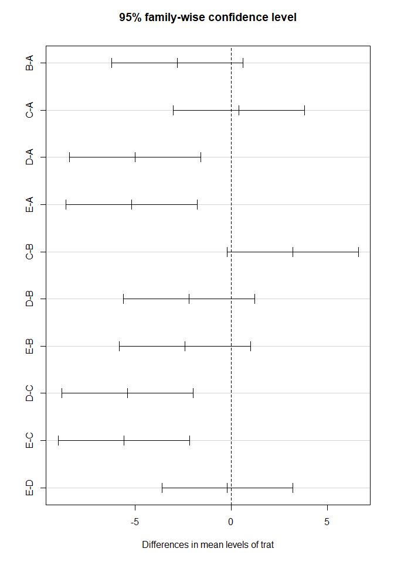

```r
plot(ingredients.tu)
```

Análise de resíduos

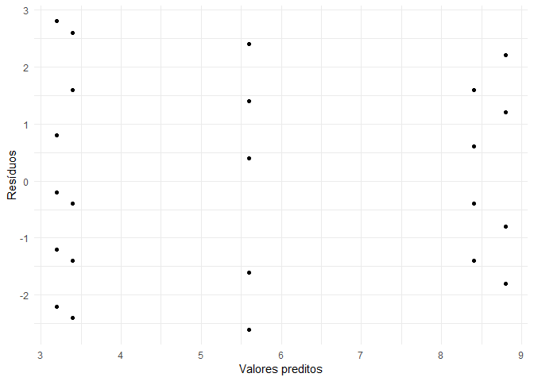

```r
# Adicionando a coluna dos resíduos e valores preditos ao dados:
ingredients <- ingredients %>%
  mutate(res = residuals(ingredients.av), vp = fitted(ingredients.av))

# Gráfico dos resíduos vs valores preditos:
ingredients %>%
  ggplot(aes(x = vp, y = res)) +
  geom_point() +
  labs(x = "Valores preditos", y = "Resíduos") +
  theme_minimal()
```

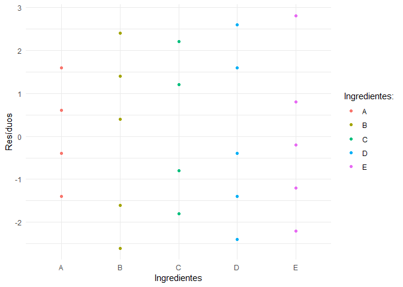

```r
# Gráfico dos resíduos vs variáveis de interesse (tratamento):
ingredients %>%
  ggplot(aes(x = trat, y = res, colour = trat)) +
  geom_point() +
  scale_color_discrete(name = "Ingredientes:") +
  labs(x = "Ingredientes", y = "Resíduos") +
  theme_minimal()
```

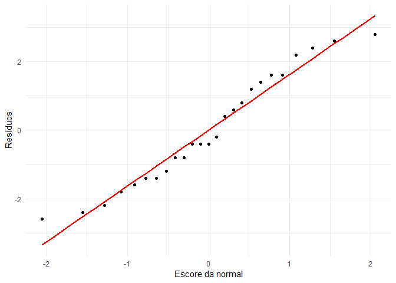

```r
# Gráfico de probabilidade normal:
gpn <- data.frame(qqnorm(ingredients$res, plot = FALSE))
gpn %>%
  ggplot(aes(x = x, y = y)) +
  geom_point() +
  geom_smooth(method = "lm", se = FALSE, colour = "red") +
  labs(x = "Escore da normal", y = "Resíduos") +
  theme_minimal()
```

```r
# Teste de normalidade
shapiro.test(x = ingredients$res)
```

```
##
##  Shapiro-Wilk normality test
##
## data:  ingredients$res
## W = 0.95305, p-value = 0.2933
```

```r
# Testes de homogeneidade da variância (Variância não constante)
bartlett.test(formula = resp ~ trat, data = ingredients)
```

```
##
##  Bartlett test of homogeneity of variances
##
## data:  resp by trat
## Bartlett's K-squared = 1.5544, df = 4, p-value = 0.817
```

```r
# Testes de homogeneidade da variância (Variância não constante)
# Alternativa ao teste anterior sem normalidade pressuposta.
fligner.test(x = ingredients$resp, g = as.factor(ingredients$trat))
```

```
##
##  Fligner-Killeen test of homogeneity of variances
##
## data:  ingredients$resp and as.factor(ingredients$trat)
## Fligner-Killeen:med chi-squared = 1.9559, df = 4, p-value = 0.7439
```

## Anexo: texto original dos exercícios

- 4-14 (Montgomery, 1997, p. 167): The effect of five different ingredients (A, B, C, D, E) on the reaction time of a chemical process is being studied.Each batch of new material is only large enough to permit five runs to be made. Furthermore, each run requires approximately 1 1/2 hours, so only five runs can be made in one day. The experimenter decides to run the experiment as Latin square so tha day and batch effects may be systematically controled. She obtains the data that follow. Analyze the data from this experiment (use $\alpha = 0.05$) and draw conclusions.

| Batch | Day |
| --- | --- |
| - | 1 ——- 2 ——- 3 ——- 4 ——- 5 |
| 1 | A = 08 – B = 07 – D = 01 – C = 07 – E = 03 |
| 2 | C = 11 – E = 02 – A = 07 – D = 03 – B = 08 |
| 3 | B = 04 – A = 09 – C = 10 – E = 01 – D = 05 |
| 4 | D = 06 – C = 08 – E = 06 – B = 06 – A = 10 |
| 5 | E = 04 – D = 02 – B = 03 – A = 08 – C = 08 |

## Referências

- MONTGOMERY, Douglas C.. Design and analysis of experiments. 1997.